# BIO2105: Chapter 9 — Regression Analysis

Correlation, Simple Linear Regression, and Residual Diagnostics (30 Points)

Student Name: Jed Izrael J. Sta. Ana | Section: Section 4

2026-11-27

## Assignment & GitHub Submission Instructions

This R Markdown starter template (`BIO2105_Regression_Analysis.Rmd`) accompanies the **BIO2105 Chapter 9: Regression Analysis** lecture. All datasets used below (`trees` and `women`) are built directly into base R—no external packages or CSV downloads are required.

1. **Complete the Analysis:** Run each code chunk step by step in RStudio and replace the bullet prompts in every **Your Interpretation** block with your own statistical conclusions.
2. **Knit the Report:** Click **Knit** in RStudio to render this file into `BIO2105_Regression_Analysis.html` (or `.pdf`). Verify that all tables, equations, and plots display properly without errors.
3. **Organize Your GitHub Repository:** Push your completed files to a **public** GitHub repository named **`BIO2105-Regression-Analysis`** with the following structure:

```
BIO2105-Regression-Analysis/
|-- README.md                            (Mandatory)
|-- BIO2105_Regression_Analysis.R        (Mandatory)
|-- BIO2105_Regression_Analysis.Rmd      (Recommended / Starter Template)
|-- BIO2105_Regression_Analysis.html     (Mandatory: .html or .pdf rendered report)
`-- data/                                (Optional)
```

4. **Submit on Canvas:** Copy your public GitHub repository URL (e.g., `https://github.com/your-username/BIO2105-Regression-Analysis`) and submit it as a **Website URL** on Canvas before the deadline. *(Note: Submitting standalone `.R` files or screenshots directly to Canvas results in a 4-point deduction.)*

# Part I: Black Cherry Trees Dataset (`trees`) — 18 Points

The built-in `trees` dataset contains measurements of diameter (`Girth`, in inches at 4 ft 6 in above ground), `Height` (in feet), and timber `Volume` (in cubic feet) for $n = 31$ felled black cherry trees. Here, we investigate whether tree girth ($x$) can predict timber volume ($y$).

### Task 1: Variable Roles & Data Exploration (2 Points)

- **Goal:** Inspect the dataset structure and define the predictor ($x$) and response ($y$) variables.

```r
# Load built-in dataset
data(trees)

# Inspect first few rows, structure, and summary statistics
head(trees)
```

```
##   Girth Height Volume
## 1   8.3     70   10.3
## 2   8.6     65   10.3
## 3   8.8     63   10.2
## 4  10.5     72   16.4
## 5  10.7     81   18.8
## 6  10.8     83   19.7
```

```r
str(trees)
```

```
## 'data.frame':    31 obs. of  3 variables:
##  $ Girth : num  8.3 8.6 8.8 10.5 10.7 10.8 11 11 11.1 11.2 ...
##  $ Height: num  70 65 63 72 81 83 66 75 80 75 ...
##  $ Volume: num  10.3 10.3 10.2 16.4 18.8 19.7 15.6 18.2 22.6 19.9 ...
```

```r
summary(trees[, c("Girth", "Volume")])
```

```
##      Girth           Volume
##  Min.   : 8.30   Min.   :10.20
##  1st Qu.:11.05   1st Qu.:19.40
##  Median :12.90   Median :24.20
##  Mean   :13.25   Mean   :30.17
##  3rd Qu.:15.25   3rd Qu.:37.30
##  Max.   :20.60   Max.   :77.00
```

**Your Interpretation (Task 1):**

The `trees` dataset contains 31 observations and three numerical variables: Girth, Height, and Volume. Girth ranges from 8.30 to 20.60 inches, with a mean of 13.25 inches. Volume ranges from 10.20 to 77.00 cubic feet, with a mean of 30.17 cubic feet.

The predictor variable ($x$) is Girth, measured in inches, while the response variable ($y$) is Volume, measured in cubic feet. Girth is used to estimate timber volume. Correlation is symmetric because it measures the relationship between two variables without assigning predictor and response roles: $r(x,y)=r(y,x)$. Regression is not symmetric because it assigns specific roles to the variables; changing the response and predictor changes the regression model.

### Task 2: Scatter Plot with Fitted Regression Line (3 Points)

- **Goal:** Visualize the linear relationship between `Girth` ($x$) and `Volume` ($y$) and overlay the Ordinary Least Squares (OLS) regression line.

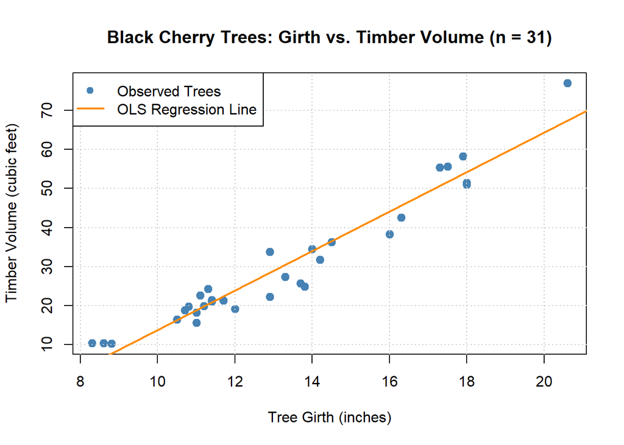

```r
# Fit simple linear regression model
tree_model <- lm(Volume ~ Girth, data = trees)

# Create scatter plot with OLS regression line
plot(trees$Girth, trees$Volume,
     xlab = "Tree Girth (inches)",
     ylab = "Timber Volume (cubic feet)",
     main = "Black Cherry Trees: Girth vs. Timber Volume (n = 31)",
     pch = 19, col = "steelblue", cex = 1.2)

grid(col = "gray80")
abline(tree_model, col = "darkorange", lwd = 2)

legend("topleft",
       legend = c("Observed Trees", "OLS Regression Line"),
       pch = c(19, NA),
       lty = c(NA, 1),
       col = c("steelblue", "darkorange"),
       lwd = c(NA, 2))
```

**Your Interpretation (Task 2):**

The scatter plot shows a strong, positive, approximately linear relationship between tree Girth and timber Volume. This means that trees with larger girths generally tend to have greater timber volumes. The upward-sloping OLS regression line summarizes this positive trend.

### Task 3: Pearson’s Correlation Coefficient ($r$) — Built-in vs. Manual Formula (3 Points)

- **Goal:** Compute Pearson’s $r$ using `cor()`, verify it manually using the standardized average product formula, and test for statistical significance using `cor.test()`.

$$r =
\frac{1}{n-1}\sum_{i=1}^{n}\left(\frac{x_i -
\bar{x}}{s_x}\right)\left(\frac{y_i - \bar{y}}{s_y}\right)$$

```r
# Built-in Pearson correlation
r_builtin <- cor(trees$Girth, trees$Volume)
print(paste("Built-in correlation r =", round(r_builtin, 6)))
```

```
## [1] "Built-in correlation r = 0.967119"
```

```r
# Manual calculation using standardized units
n <- nrow(trees)
x_bar <- mean(trees$Girth)
y_bar <- mean(trees$Volume)
s_x <- sd(trees$Girth)
s_y <- sd(trees$Volume)

r_manual <- (1 / (n - 1)) * sum(((trees$Girth - x_bar) / s_x) * ((trees$Volume - y_bar) / s_y))
print(paste("Manual correlation r   =", round(r_manual, 6)))
```

```
## [1] "Manual correlation r   = 0.967119"
```

```r
# Significance test for correlation
cor.test(trees$Girth, trees$Volume)
```

```
##
##  Pearson's product-moment correlation
##
## data:  trees$Girth and trees$Volume
## t = 20.478, df = 29, p-value < 2.2e-16
## alternative hypothesis: true correlation is not equal to 0
## 95 percent confidence interval:
##  0.9322519 0.9841887
## sample estimates:
##       cor
## 0.9671194
```

**Your Interpretation (Task 3):**

The built-in and manual calculations both give a Pearson correlation coefficient of $r=0.9671$, confirming that the two methods agree. This indicates a very strong positive linear relationship between Girth and Volume. The correlation test gives $t=20.478$, with 29 degrees of freedom and a $p$-value less than $2.2\times10^{-16}$. Since the p-value is below 0.05, there is statistically significant evidence of a linear correlation between tree Girth and timber Volume.

### Task 4: Invariance Under Linear Transformation (2 Points)

- **Goal:** Verify the theorem $r(cx + d, ay + b) = r(x, y)$ for $c > 0, a > 0$ by converting `Girth` from inches to centimeters ($1\text{ in} = 2.54\text{ cm}$) and `Volume` from cubic feet to liters ($1\text{ ft}^3 = 28.3168\text{ L}$).

```r
# Convert units (linear scaling with positive constants)
girth_cm <- 2.54 * trees$Girth
volume_L <- 28.3168 * trees$Volume

# Compare correlation before and after unit conversion
r_metric <- cor(girth_cm, volume_L)

print(paste("Original r (in, ft^3):", round(r_builtin, 6)))
```

```
## [1] "Original r (in, ft^3): 0.967119"
```

```r
print(paste("Metric r   (cm, L)   :", round(r_metric, 6)))
```

```
## [1] "Metric r   (cm, L)   : 0.967119"
```

```r
print(paste("Absolute difference  :", abs(r_builtin - r_metric)))
```

```
## [1] "Absolute difference  : 2.22044604925031e-16"
```

**Your Interpretation (Task 4):**

After converting Girth from inches to centimeters and Volume from cubic feet to liters, the correlation remains approximately $r=0.9671$. Pearson’s correlation is unchanged because multiplying each variable by a positive constant changes its measurement scale but not the direction or strength of its linear association. The regression slope does not remain numerically invariant: its units change from cubic feet per inch to liters per centimeter. The converted slope is the original slope multiplied by $28.3168/2.54$.

### Task 5: Simple Linear Regression Estimation & Centroid Property (3 Points)

- **Goal:** Extract the OLS estimates $b_0$ and $b_1$, verify $b_1 = r \cdot (s_y / s_x)$, and confirm that the regression line passes through the centroid $(\bar{x}, \bar{y})$.

```r
# Extract model coefficients
coeffs <- coef(tree_model)
b0 <- coeffs[1]
b1 <- coeffs[2]
print(coeffs)
```

```
## (Intercept)       Girth
##  -36.943459    5.065856
```

```r
# Verify slope relationship with r: b1 = r * (s_y / s_x)
b1_from_r <- r_builtin * (s_y / s_x)
print(paste("Slope from lm()        :", round(b1, 6)))
```

```
## [1] "Slope from lm()        : 5.065856"
```

```r
print(paste("Slope from r*(s_y/s_x) :", round(b1_from_r, 6)))
```

```
## [1] "Slope from r*(s_y/s_x) : 5.065856"
```

```r
# Verify regression line passes through (x_bar, y_bar)
y_hat_at_xbar <- b0 + b1 * x_bar
print(paste("Sample mean y_bar      :", round(y_bar, 6)))
```

```
## [1] "Sample mean y_bar      : 30.170968"
```

```r
print(paste("Predicted y at x_bar   :", round(y_hat_at_xbar, 6)))
```

```
## [1] "Predicted y at x_bar   : 30.170968"
```

**Your Interpretation (Task 5):**

The fitted regression equation is $\widehat{Volume}=-36.9435+5.0659(Girth)$, where Girth is measured in inches and predicted Volume is measured in cubic feet. For every one-inch increase in Girth, the predicted timber Volume increases by approximately 5.0659 cubic feet. The manual slope calculation also gives 5.0659, verifying the slope formula. The regression line passes through the centroid because the predicted Volume at the mean Girth is equal to the mean Volume (approximately 30.1710 cubic feet). The intercept is the model’s predicted Volume when Girth is zero; because zero is outside the observed Girth range and is not realistic for these trees, it does not have a meaningful practical interpretation.

### Task 6: Coefficient of Determination ($R^2$) (2 Points)

- **Goal:** Compute $R^2$ from the model summary and verify that $R^2 = r^2$ in simple linear regression.

```r
r_squared <- summary(tree_model)$r.squared
print(paste("R-squared from summary():", round(r_squared, 6)))
```

```
## [1] "R-squared from summary(): 0.93532"
```

```r
print(paste("r^2 from correlation   :", round(r_builtin^2, 6)))
```

```
## [1] "r^2 from correlation   : 0.93532"
```

**Your Interpretation (Task 6):**

The coefficient of determination is $R^2=0.9353$, or 93.53%. This means that approximately 93.53% of the variation in timber Volume among the sampled trees is explained by Girth in the simple linear regression model. The remaining 6.47% is not explained by Girth in this model. The value also agrees with the squared Pearson correlation coefficient, $r^2$.

### Task 7: Inference for Slope & Confidence vs. Prediction Intervals (3 Points)

- **Goal:** Test $H_0: \beta_1 = 0$, compute the 95% confidence interval for $\beta_1$, and compare 95% confidence intervals (for mean response) against 95% prediction intervals (for individual trees) at `Girth = c(10, 14, 18)` inches.

```r
# Full regression summary and 95% CI for parameters
summary(tree_model)
```

```
##
## Call:
## lm(formula = Volume ~ Girth, data = trees)
##
## Residuals:
##    Min     1Q Median     3Q    Max
## -8.065 -3.107  0.152  3.495  9.587
##
## Coefficients:
##             Estimate Std. Error t value Pr(>|t|)
## (Intercept) -36.9435     3.3651  -10.98 7.62e-12 ***
## Girth         5.0659     0.2474   20.48  < 2e-16 ***
## ---
## Signif. codes:  0 '***' 0.001 '**' 0.01 '*' 0.05 '.' 0.1 ' ' 1
##
## Residual standard error: 4.252 on 29 degrees of freedom
## Multiple R-squared:  0.9353, Adjusted R-squared:  0.9331
## F-statistic: 419.4 on 1 and 29 DF,  p-value: < 2.2e-16
```

```r
confint(tree_model, level = 0.95)
```

```
##                  2.5 %     97.5 %
## (Intercept) -43.825953 -30.060965
## Girth         4.559914   5.571799
```

```r
# New girth values for prediction
new_trees <- data.frame(Girth = c(10, 14, 18))

# 95% Confidence Interval for MEAN volume
ci_mean <- predict(tree_model, newdata = new_trees, interval = "confidence", level = 0.95)
print("95% Confidence Intervals (Mean Response):")
```

```
## [1] "95% Confidence Intervals (Mean Response):"
```

```r
print(round(ci_mean, 3))
```

```
##      fit    lwr    upr
## 1 13.715 11.448 15.982
## 2 33.979 32.371 35.586
## 3 54.242 51.375 57.109
```

```r
# 95% Prediction Interval for INDIVIDUAL tree volume
pi_indiv <- predict(tree_model, newdata = new_trees, interval = "prediction", level = 0.95)
print("95% Prediction Intervals (Individual Response):")
```

```
## [1] "95% Prediction Intervals (Individual Response):"
```

```r
print(round(pi_indiv, 3))
```

```
##      fit    lwr    upr
## 1 13.715  4.728 22.702
## 2 33.979 25.135 42.822
## 3 54.242 45.085 63.399
```

**Your Interpretation (Task 7):**

The slope test evaluates $H_0:\beta_1=0$ against $H_a:\beta_1\ne0$. The test gives $t=20.4783$ with 29 degrees of freedom and a p-value below 0.05. Therefore, the null hypothesis is rejected, indicating a statistically significant linear relationship between Girth and Volume. The 95% confidence interval for the population slope is approximately 4.5599 to 5.5718; because it does not include zero, it supports this conclusion.

At a Girth of 14 inches, the predicted Volume is approximately 33.9785 cubic feet. The 95% confidence interval for the mean response is approximately 32.3710 to 35.5861 cubic feet, while the 95% prediction interval for an individual tree is approximately 25.1349 to 42.8222 cubic feet. The prediction interval is wider because it includes both uncertainty in estimating the mean response and the additional tree-to-tree random variation. The prediction interval therefore has an additional error component compared with the confidence interval for the mean.

# Part II: American Women Height & Weight Dataset (`women`) — 12 Points

The built-in `women` dataset provides average weights (`weight`, in lbs) for American women aged 30–39 across $n = 15$ discrete heights (`height`, in inches, from 58 to 72 inches). We fit a simple linear regression predicting `weight` ($y$) from `height` ($x$) and evaluate model assumptions.

### Task 8: Model Fitting & Scatter Plot (3 Points)

- **Goal:** Fit `lm(weight ~ height, data = women)`, inspect the model summary, and plot the data with the fitted line.

```r
data(women)
head(women)
```

```
##   height weight
## 1     58    115
## 2     59    117
## 3     60    120
## 4     61    123
## 5     62    126
## 6     63    129
```

```r
women_model <- lm(weight ~ height, data = women)
summary(women_model)
```

```
##
## Call:
## lm(formula = weight ~ height, data = women)
##
## Residuals:
##     Min      1Q  Median      3Q     Max
## -1.7333 -1.1333 -0.3833  0.7417  3.1167
##
## Coefficients:
##              Estimate Std. Error t value Pr(>|t|)
## (Intercept) -87.51667    5.93694  -14.74 1.71e-09 ***
## height        3.45000    0.09114   37.85 1.09e-14 ***
## ---
## Signif. codes:  0 '***' 0.001 '**' 0.01 '*' 0.05 '.' 0.1 ' ' 1
##
## Residual standard error: 1.525 on 13 degrees of freedom
## Multiple R-squared:  0.991,  Adjusted R-squared:  0.9903
## F-statistic:  1433 on 1 and 13 DF,  p-value: 1.091e-14
```

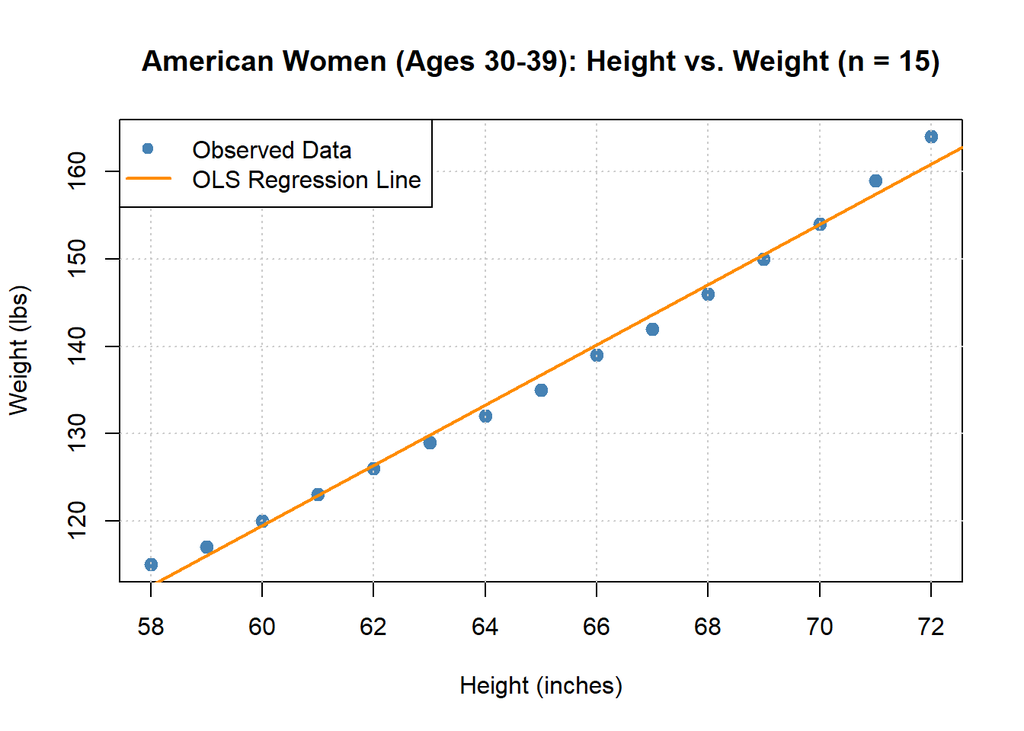

```r
plot(women$height, women$weight,
     xlab = "Height (inches)",
     ylab = "Weight (lbs)",
     main = "American Women (Ages 30-39): Height vs. Weight (n = 15)",
     pch = 19, col = "steelblue", cex = 1.2)
grid(col = "gray80")
abline(women_model, col = "darkorange", lwd = 2)
legend("topleft",
       legend = c("Observed Data", "OLS Regression Line"),
       pch = c(19, NA), lty = c(NA, 1),
       col = c("steelblue", "darkorange"), lwd = c(NA, 2))
```

**Your Interpretation (Task 8):**

The fitted regression equation is $\widehat{Weight}=-87.5167+3.4500(Height)$, where Height is measured in inches and predicted Weight is measured in pounds. For every one-inch increase in height, the predicted weight increases by approximately 3.45 pounds. The coefficient of determination is $R^2=0.9910$, meaning that approximately 99.10% of the variation in weight is explained by height in this linear model. The p-value for the slope is $1.09\times10^{-14}$, which is below 0.05 and indicates a statistically significant positive linear association. Based only on the high $R^2$ and the scatter plot, the linear fit appears very strong. However, the diagnostic plots in Task 10 must also be considered before deciding whether the model assumptions are appropriate.

### Task 9: ANOVA Table & Sum of Squares Decomposition (4 Points)

- **Goal:** Generate the ANOVA table via `anova()` and manually verify the sum-of-squares identity:

$$SS_{\text{Total}} =
SS_{\text{Regression}} + SS_{\text{Error}}$$

```r
# Built-in ANOVA table
anova(women_model)
```

```
## Analysis of Variance Table
##
## Response: weight
##           Df Sum Sq Mean Sq F value    Pr(>F)
## height     1 3332.7  3332.7    1433 1.091e-14 ***
## Residuals 13   30.2     2.3
## ---
## Signif. codes:  0 '***' 0.001 '**' 0.01 '*' 0.05 '.' 0.1 ' ' 1
```

```r
# Manual sum of squares calculation using fitted() and residuals()
y_obs  <- women$weight
y_hat  <- fitted(women_model)
res    <- residuals(women_model)
y_mean <- mean(y_obs)

ss_total <- sum((y_obs - y_mean)^2)
ss_reg   <- sum((y_hat - y_mean)^2)
ss_error <- sum(res^2)

print(paste("SS_Total             :", round(ss_total, 4)))
```

```
## [1] "SS_Total             : 3362.9333"
```

```r
print(paste("SS_Reg               :", round(ss_reg, 4)))
```

```
## [1] "SS_Reg               : 3332.7"
```

```r
print(paste("SS_Error             :", round(ss_error, 4)))
```

```
## [1] "SS_Error             : 30.2333"
```

```r
print(paste("SS_Reg + SS_Error    :", round(ss_reg + ss_error, 4)))
```

```
## [1] "SS_Reg + SS_Error    : 3362.9333"
```

```r
print(paste("R^2 = SS_Reg/SS_Total:", round(ss_reg / ss_total, 6)))
```

```
## [1] "R^2 = SS_Reg/SS_Total: 0.99101"
```

```r
# Verify F = t^2 for simple linear regression
f_anova <- anova(women_model)[1, "F value"]
t_slope <- summary(women_model)$coefficients["height", "t value"]
print(paste("ANOVA F-statistic:", round(f_anova, 4)))
```

```
## [1] "ANOVA F-statistic: 1433.0243"
```

```r
print(paste("Slope t-statistic squared:", round(t_slope^2, 4)))
```

```
## [1] "Slope t-statistic squared: 1433.0243"
```

**Your Interpretation (Task 9):**

The ANOVA table gives a regression sum of squares ($SS_{Reg}$) of 3332.7000, an error sum of squares ($SS_{Error}$) of 30.2333, and a total sum of squares ($SS_{Total}$) of 3362.9333. The sum-of-squares identity is satisfied because $3332.7000+30.2333=3362.9333$. The ANOVA F-statistic is approximately 1433. The slope t-statistic from Task 8 is approximately 37.85, and its square is approximately 1432.6; this agrees with the ANOVA F-statistic, allowing for rounding. The ratio $SS_{Reg}/SS_{Total}$ is approximately 0.9910, matching the model’s $R^2$.

### Task 10: Residual Diagnostics & Assumption Checking (5 Points)

- **Goal:** Inspect the **Residuals vs. Fitted** plot and the **Normal Q–Q** plot to check linearity, constant variance (homoscedasticity), and normality of residuals.

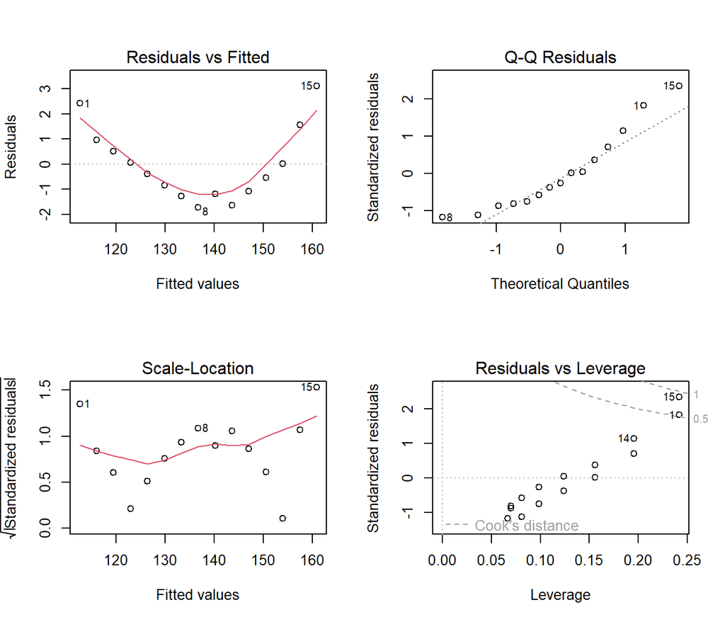

```r
# 2x2 standard R diagnostic panel
par(mfrow = c(2, 2))
plot(women_model)
```

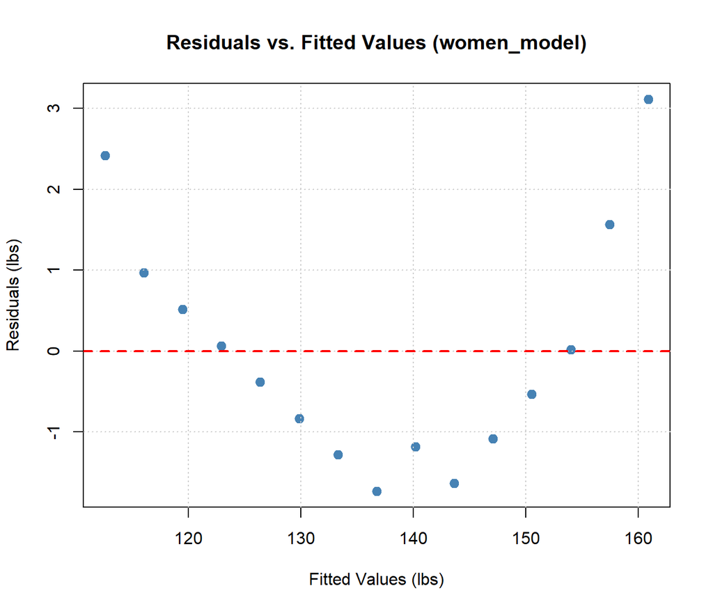

```r
par(mfrow = c(1, 1))

# Dedicated Residuals vs. Fitted plot with zero reference line
plot(fitted(women_model), residuals(women_model),
     xlab = "Fitted Values (lbs)",
     ylab = "Residuals (lbs)",
     main = "Residuals vs. Fitted Values (women_model)",
     pch = 19, col = "steelblue", cex = 1.2)
grid(col = "gray80")
abline(h = 0, col = "red", lty = 2, lwd = 2)
```

**Your Interpretation (Task 10):**

**Linearity and constant variance:** The Residuals vs. Fitted plot shows a systematic curved, approximately U-shaped pattern rather than random scatter around zero. Residuals are mostly negative in the middle fitted values and positive toward the lower and higher fitted values. This pattern suggests that a straight-line model does not fully capture the relationship between height and weight; a curved relationship may be more appropriate. The spread also varies somewhat across fitted values, so the constant variance assumption should be examined rather than assumed to hold.

**Normality:** In the Normal Q–Q plot, many points near the middle follow the reference line reasonably closely, but the points at the ends show noticeable departures. This suggests that the residuals may not be perfectly normally distributed, particularly in the tails.

**Conclusion:** Although the model has a high $R^2$ of 0.9910, the residual pattern indicates that a high proportion of explained variation does not by itself guarantee that the linearity, constant variance, and normality assumptions are all satisfied. A quadratic or other polynomial model may better represent the curved relationship between height and weight. This alternative would need to be fitted and assessed before concluding that it is more appropriate.

## Final Submission Checklist

Before submitting your GitHub URL on Canvas, verify that you have completed every item below:

- Public GitHub repository **`BIO2105-Regression-Analysis`** contains all mandatory files (`README.md`, `BIO2105_Regression_Analysis.R`, `BIO2105_Regression_Analysis.Rmd`, and `BIO2105_Regression_Analysis.html` or `.pdf`).
- `README.md` clearly describes the project objectives, repository structure, and steps to reproduce the analysis.
- Knitted report (`.html` or `.pdf`) displays all code outputs, tables, and diagnostic plots without errors.
- All $t$-statistics, $F$-statistics, degrees of freedom, $p$-values, confidence/prediction intervals, and $R^2$ values are accurately reported in your written interpretations.
- Public GitHub repository URL is submitted on Canvas before the deadline.